## ## Computer Assignment 5 Answers File

## Please write your answers into the space below the questions. Knit this file when you are done to check that all code runs. Remember to rename the file to contain *your actual* Last and First name.

```r
library(seqinr)
library(tidyverse)
```

```r
library(ggplot2)
source("pairAlign.R")
if (!requireNamespace("BiocManager", quietly = TRUE))
    install.packages("BiocManager")
BiocManager::install("Biostrings")
suppressMessages(library(Biostrings)) #silently loads Biostrings functions
```

1.1

```r
lut <- matrix(-1, 4, 4)
diag(lut) <- 3
dimnames(lut) <- list(c("A", "C", "G", "T"), c("A", "C", "G", "T"))

smith_algorithm<-function(seq1,seq2){
  scoreMat <- scoreMat <- lut[strsplit(seq2, "")[[1]], strsplit(seq1, "")[[1]]]

  #convert seq1 and seq2 strings to vector
  seq1 <- strsplit(seq1, "")[[1]]
  seq2 <- strsplit(seq2, "")[[1]]

  amatrix<- matrix(0, ncol=length(seq1)+1, nrow=length(seq2)+1) #initialize alignment matrix
  rownames(amatrix) <-c("", seq2) #set row names
  colnames(amatrix) <-c("", seq1) #set column names

  gap <- -2

  # set values of the first row and column:
  for (i in 1:nrow(amatrix)) {
    amatrix[i,1] <- gap * (i - 1)
  }

  for (j in 1:ncol(amatrix)) {
    amatrix[1,j] <- gap * (j - 1)
  }

  # use max[(D + score(), U + gap, L + gap)] for the rest of the columns to determine the best score for each entry\
  for (i in 2:nrow(amatrix)) {
    for (j in 2:ncol(amatrix)) {
      U <- amatrix[i - 1, j] + gap
      L <- amatrix[i, j - 1] + gap
      D <- amatrix[i - 1, j - 1] + scoreMat[i - 1, j - 1]
      amatrix[i, j] <- max(U, L, D, 0)
    }
  }

  return(amatrix)
}
```

1.2

```r
seq1 <- "CCGATATGGCTTATGATCCA"
seq2 <- "GATTACAGGGCTTAAGCT"

smith_algorithm(seq1, seq2)
```

```
##        C  C  G  A   T   A   T   G   G   C   T   T   A   T   G   A   T   C   C
##     0 -2 -4 -6 -8 -10 -12 -14 -16 -18 -20 -22 -24 -26 -28 -30 -32 -34 -36 -38
## G  -2  0  0  0  0   0   0   0   0   0   0   0   0   0   0   0   0   0   0   0
## A  -4  0  0  0  3   1   3   1   0   0   0   0   0   3   1   0   3   1   0   0
## T  -6  0  0  0  1   6   4   6   4   2   0   3   3   1   6   4   2   6   4   2
## T  -8  0  0  0  0   4   5   7   5   3   1   3   6   4   4   5   3   5   5   3
## A -10  0  0  0  3   2   7   5   6   4   2   1   4   9   7   5   8   6   4   4
## C -12  0  3  1  1   2   5   6   4   5   7   5   3   7   8   6   6   7   9   7
## A -14  0  1  2  4   2   5   4   5   3   5   6   4   6   6   7   9   7   7   8
## G -16  0  0  4  2   3   3   4   7   8   6   4   5   4   5   9   7   8   6   6
## G -18  0  0  3  3   1   2   2   7  10   8   6   4   4   3   8   8   6   7   5
## G -20  0  0  3  2   2   0   1   5  10   9   7   5   3   3   6   7   7   5   6
## C -22  0  3  1  2   1   1   0   3   8  13  11   9   7   5   4   5   6  10   8
## T -24  0  1  2  0   5   3   4   2   6  11  16  14  12  10   8   6   8   8   9
## T -26  0  0  0  1   3   4   6   4   4   9  14  19  17  15  13  11   9   7   7
## A -28  0  0  0  3   1   6   4   5   3   7  12  17  22  20  18  16  14  12  10
## A -30  0  0  0  3   2   4   5   3   4   5  10  15  20  21  19  21  19  17  15
## G -32  0  0  3  1   2   2   3   8   6   4   8  13  18  19  24  22  20  18  16
## C -34  0  3  1  2   0   1   1   6   7   9   7  11  16  17  22  23  21  23  21
## T -36  0  1  2  0   5   3   4   4   5   7  12  10  14  19  20  21  26  24  22
##     A
##   -40
## G   0
## A   3
## T   1
## T   1
## A   6
## C   5
## A  10
## G   8
## G   6
## G   4
## C   6
## T   7
## T   8
## A  10
## A  13
## G  14
## C  19
## T  20
```

1.3

```r
sub <- nucleotideSubstitutionMatrix(match = 3, mismatch = -1, baseOnly = TRUE)
pairAlign(seq1, seq2, substitutionMatrix = sub, gapExtension = -2, type = "local")
```

```
## $Pattern
## [1] "GA-T--ATGGCTTATGAT"
##
## $Subject
## [1] "GATTACAGGGCTTAAGCT"
##
## $Score
## [1] 27
```

2.1

```r
#modified version of generateSeqsWithMultinomialModel() from https://a-little-book-of-r-for-bioinformatics.readthedocs.io/en/latest/src/chapter4.html

generateSeqs <- function(inputsequence, X){
  #split inputted string into vector of individual characters
  inputsequencevector <- strsplit(inputsequence,"")[[1]]
  mylength <- length(inputsequencevector)
  mytable <- table(inputsequencevector)
  letters <- rownames(mytable)
  probabilities <- mytable/mylength #store the probabilities of letters

  #sample total number of characters needed to generate X random sequences of length myLength
  seqset <- sample(letters, mylength*X, rep=TRUE, prob=probabilities)

  #apply paste0() to collapse vector of characters into a vector of character strings of the original length
  seqs <- vapply(seq(1, mylength*X, mylength), function(i) paste0(seqset[i:(i+(mylength-1))], collapse = ''), inputsequence)

  return(seqs)
}
```

```r
seqs <- generateSeqs("ARDCRKRHBD", 1500)
scores <- rep(NA, 1500)

for (i in 1:1500) {
  score <- pairAlign("QGHDPKACRKZNCL", seqs[i], substitutionMatrix = "BLOSUM62",
                             gapOpening = -8, gapExtension = -2, type = "global", scoreOnly = TRUE)

  scores[i] <- score
}
```

2.2

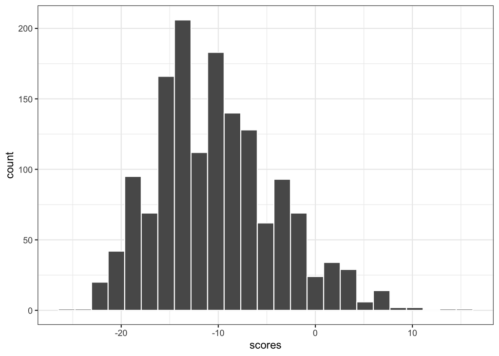

```r
# Creating the histogram
ggplot(dat = data.frame(scores), aes(scores)) +
  geom_histogram(col="white", bins = 25) +
  theme_bw()
```

```r
# Calculating Probablity of a score greater than or equal to -4
greater_than_4 <- scores[scores >= -4]
(p <- length(greater_than_4) / length(scores))
```

```
## [1] 0.1833333
```

```r
# INPUT ARGUMENTS
# patterns : list of char vectors
#            each vector patterns[[i]] contains the version of the CENTER sequence that arises from the pairwise alignment between the center sequence and sequence[i]
# subjects : list of char vectors
#            each vector subjects[[i]] contains the alignment of sequence[i] after a pairwise alignment with the center sequence
# center   : integer
#            index of the sequence in the original sequence list that is the center.
buildMSA <- function(patterns, subjects, center) {
    MSA <- rbind(patterns[[1]], subjects[[1]])
    for(i in 2:length(patterns)) {
        j = 1 #index in new row
        k = 1 #index in alignment of center sequence to sequence i
        m = 1 #column index of MSA
        maxLength = ncol(MSA) + length(patterns[[i]])
        newRow = character(maxLength)
        while(k <= length(patterns[[i]]) && m <= ncol(MSA)) {
            if(patterns[[i]][k] == MSA[1, m]) {
                newRow[j] <- subjects[[i]][k]
                j <- j + 1
                k <- k + 1
                m <- m + 1
            } else if(MSA[1, m] == "-") {
                newRow[j] <- "-"
                j <- j + 1
                m <- m + 1
            } else if(patterns[[i]][k] == "-") {
                if(m == 1) {
                    MSA <- cbind(rep("-", nrow(MSA)), MSA)
                } else {
                    MSA <- cbind(MSA[, 1:(m-1)], rep("-", nrow(MSA)), MSA[, m:ncol(MSA)])
                }
                newRow[j] <- subjects[[i]][k]
                m <- m + 1
                j <- j + 1
                k <- k + 1
            }
        }
        while(k <= length(patterns[[i]])) {
            MSA <- cbind(MSA, rep("-", nrow(MSA)))
            newRow[j] <- subjects[[i]][k]
            k <- k + 1
            j <- j + 1
        }
        while(m <= ncol(MSA)) {
            newRow[j] <- "-"
            m <- m + 1
            j <- j + 1
        }
        newRow <- newRow[1:(m - 1)]
        MSA <- rbind(MSA, newRow)
    }
    rownames(MSA) <- c("    Center:", paste0("Sequence ", 1:(nrow(MSA)), ":")[-center])
    colnames(MSA) <- 1:ncol(MSA)
    return(MSA)
}
```

```r
## EXAMPLE:
peptides <- c("ARDCRKRHBD", "QGHDPKACRKZNCL", "ACGDCRKRHBD")
n <- length(peptides)
align1 <- matrix("", n, n)
align2 <- align1

## Generate alignments
for(i in 1:(n-1)) {
    for(j in (i+1):n) {
        alignment <- pairAlign(peptides[i], peptides[j], "BLOSUM62", -8, -2)
        align1[j, i] <- alignment[[1]]
        align2[i, j] <- alignment[[1]]
        align2[j, i] <- alignment[[2]]
        align1[i, j] <- alignment[[2]]
    }
}

distances <- sapply(mapply(`!=`, strsplit(align1, ""), strsplit(align2, "")), sum)
distanceMatrix <- matrix(distances, n, n)
dimnames(distanceMatrix) = list(peptides, peptides)

possibleCenters <- which(colSums(distanceMatrix) == min(colSums(distanceMatrix)))
center <- possibleCenters[which.max(nchar(peptides[possibleCenters]))]

ps <- strsplit(align1[,center][-center], "")
ss <- strsplit(align2[,center][-center], "")
ps
```

```
## [[1]]
##  [1] "A" "C" "G" "D" "C" "R" "K" "R" "H" "B" "D"
##
## [[2]]
##  [1] "A" "C" "G" "D" "-" "-" "-" "C" "R" "K" "R" "H" "B" "D"
```

```r
ss
```

```
## [[1]]
##  [1] "A" "-" "R" "D" "C" "R" "K" "R" "H" "B" "D"
##
## [[2]]
##  [1] "Q" "G" "H" "D" "P" "K" "A" "C" "R" "K" "Z" "N" "C" "L"
```

```r
buildMSA(ps, ss, center)
```

```
##             1   2   3   4   5   6   7   8   9   10  11  12  13  14
##     Center: "A" "C" "G" "D" "-" "-" "-" "C" "R" "K" "R" "H" "B" "D"
## Sequence 1: "A" "-" "R" "D" "-" "-" "-" "C" "R" "K" "R" "H" "B" "D"
## Sequence 2: "Q" "G" "H" "D" "P" "K" "A" "C" "R" "K" "Z" "N" "C" "L"
```

3.1a The buildMSA() function takes in three arguments, pattern, subjects, center. The center is just simply which of the sequences is the center of our alignment. For the pattern and subjects, remember that we are comparing each pairwise sequence alignment, and calculating the distance between each alignment pairs and finding the sequence that would minimuzie the sum of these distances which is the center. Then, the pattern is storing the alignment of the center sequence for each of these pairwise alignment, and subjects storing each of the subject of the pairwise alignments against the center sequence. buildMSA() takes these patterns and subjects, and creates the multiple sequence alignment that aligns all these subjects to the center sequence, using the pattersn found for each center sequence pair.

3.2 The nested for loop iterates over the vecitor peptides by comparing the ith and jth sequence in the peptide, such that i and j and not the same (so not including diagonal elements in matrix), and such that the same i and j are not repeated twice. Then, this is pairAligned, and the alignment sequences are stored into two alignment matrices representing the sequence alignment and its counterpart/

3.3

```r
sequences <- c("MATCHQQQ", "MARCH", "MATCH", "QQQMATCH", "MATQQQCH")
n <- length(sequences)
pattern <- matrix("", n, n)
subject <- pattern

## Generate alignments
for (i in 1:(n-1)) {
    for (j in (i+1):n) {
        alignment <- pairAlign(sequences[i], sequences[j], substitutionMatrix="BLOSUM62", gapOpening=-10, gapExtension=-2)
        pattern[j, i] <- alignment[[1]]
        subject[i, j] <- alignment[[1]]
        subject[j, i] <- alignment[[2]]
        pattern[i, j] <- alignment[[2]]
    }
}

pattern
```

```
##      [,1]          [,2]       [,3]       [,4]          [,5]
## [1,] ""            "MARCH---" "MATCH---" "QQQMATCH---" "MATQQQCH"
## [2,] "MATCHQQQ"    ""         "MATCH"    "QQQMATCH"    "MATQQQCH"
## [3,] "MATCHQQQ"    "MARCH"    ""         "QQQMATCH"    "MATQQQCH"
## [4,] "---MATCHQQQ" "---MARCH" "---MATCH" ""            "MATQQQCH"
## [5,] "MATCHQQQ"    "MA---RCH" "MAT---CH" "QQQMATCH"    ""
```

3.4

```r
distances <- sapply(mapply(`!=`, strsplit(pattern, ""), strsplit(subject, "")), sum)
distanceMatrix <- matrix(distances, n, n)
dimnames(distanceMatrix) = list(sequences, sequences)
distanceMatrix
```

```
##          MATCHQQQ MARCH MATCH QQQMATCH MATQQQCH
## MATCHQQQ        0     4     3        6        4
## MARCH           4     0     1        4        4
## MATCH           3     1     0        3        3
## QQQMATCH        6     4     3        0        6
## MATQQQCH        4     4     3        6        0
```

3.5 finding the column sums is useful because it sums up all the distances for the given pattern sequence, and since then center sequence is that which thew sum of the distances between it and all other subject sequences is the least, we will just need to find the sequence whose sum of distances (which is the column sum) is the least, and has the most number of nucleotide (greatesting number of characters)

3.6

```r
possibleCenters <- which(colSums(distanceMatrix) == min(colSums(distanceMatrix)))
center <- possibleCenters[which.max(nchar(sequences[possibleCenters]))]
```

I took similar steps to the example we were provided. I collected the total sums (column sums) for each possible center sequence, and stored all possible center sequences in a variable called possibleCenters, and then in the case that there are multiple potential center sequences due to have the same distance sum, we choose the one whith the greatest number of characters as our center sequence.

3.7

```r
patterns <- strsplit(pattern[,center][-center], "")
subjects <- strsplit(subject[,center][-center], "")
patterns
```

```
## [[1]]
## [1] "M" "A" "T" "C" "H" "-" "-" "-"
##
## [[2]]
## [1] "M" "A" "T" "C" "H"
##
## [[3]]
## [1] "-" "-" "-" "M" "A" "T" "C" "H"
##
## [[4]]
## [1] "M" "A" "T" "-" "-" "-" "C" "H"
```

```r
subjects
```

```
## [[1]]
## [1] "M" "A" "T" "C" "H" "Q" "Q" "Q"
##
## [[2]]
## [1] "M" "A" "R" "C" "H"
##
## [[3]]
## [1] "Q" "Q" "Q" "M" "A" "T" "C" "H"
##
## [[4]]
## [1] "M" "A" "T" "Q" "Q" "Q" "C" "H"
```

```r
buildMSA(patterns, subjects, center)
```

```
##             1   2   3   4   5   6   7   8   9   10  11  12  13  14
##     Center: "-" "-" "-" "M" "A" "T" "-" "-" "-" "C" "H" "-" "-" "-"
## Sequence 1: "-" "-" "-" "M" "A" "T" "-" "-" "-" "C" "H" "Q" "Q" "Q"
## Sequence 2: "-" "-" "-" "M" "A" "R" "-" "-" "-" "C" "H" "-" "-" "-"
## Sequence 4: "Q" "Q" "Q" "M" "A" "T" "-" "-" "-" "C" "H" "-" "-" "-"
## Sequence 5: "-" "-" "-" "M" "A" "T" "Q" "Q" "Q" "C" "H" "-" "-" "-"
```

3.8

```r
centerStar <- function(sequences, substitutionMatrix, gapOpening, gapExtension) {
  n <- length(sequences)
  pattern <- matrix("", n, n)
  subject <- pattern

  ## Generate alignments
  for (i in 1:(n-1)) {
      for (j in (i+1):n) {
          alignment <- pairAlign(sequences[i], sequences[j], substitutionMatrix=substitutionMatrix, gapOpening=gapOpening, gapExtension=gapExtension)
          pattern[j, i] <- alignment[[1]]
          subject[i, j] <- alignment[[1]]
          subject[j, i] <- alignment[[2]]
          pattern[i, j] <- alignment[[2]]
      }
  }

  distances <- sapply(mapply(`!=`, strsplit(pattern, ""), strsplit(subject, "")), sum)
  distanceMatrix <- matrix(distances, n, n)
  dimnames(distanceMatrix) = list(sequences, sequences)

  possibleCenters <- which(colSums(distanceMatrix) == min(colSums(distanceMatrix)))
  center <- possibleCenters[which.max(nchar(sequences[possibleCenters]))]

  patterns <- strsplit(pattern[,center][-center], "")
  subjects <- strsplit(subject[,center][-center], "")

  return(buildMSA(patterns, subjects, center))
}

globins <- unlist(seqinr::read.fasta("globins.fasta", seqtype = "AA", as.string = T))

centerStar(globins, "BLOSUM62", -10, -3)
```

```
##             1   2   3   4   5   6   7   8   9   10  11  12  13  14  15  16  17
##     Center: "M" "-" "-" "-" "-" "-" "-" "-" "-" "-" "V" "-" "L" "S" "P" "A" "D"
## Sequence 2: "M" "-" "-" "-" "-" "-" "-" "-" "-" "-" "V" "H" "L" "T" "P" "E" "E"
## Sequence 3: "M" "-" "-" "-" "-" "-" "-" "-" "-" "-" "V" "-" "L" "S" "E" "G" "E"
## Sequence 4: "M" "P" "I" "V" "D" "T" "G" "S" "V" "A" "P" "-" "L" "S" "A" "A" "E"
## Sequence 5: "-" "-" "-" "-" "-" "-" "-" "-" "-" "-" "-" "-" "L" "S" "A" "D" "Q"
## Sequence 6: "M" "G" "-" "-" "-" "-" "-" "-" "-" "-" "A" "-" "L" "T" "E" "S" "Q"
##             18  19  20  21  22  23  24  25  26  27  28  29  30  31  32  33  34
##     Center: "K" "T" "N" "V" "K" "A" "A" "W" "G" "K" "V" "-" "G" "A" "H" "A" "G"
## Sequence 2: "K" "S" "A" "V" "T" "A" "L" "W" "G" "K" "V" "-" "-" "-" "N" "V" "D"
## Sequence 3: "W" "Q" "L" "V" "L" "H" "V" "W" "A" "K" "V" "-" "E" "A" "D" "V" "A"
## Sequence 4: "K" "T" "K" "I" "R" "S" "A" "W" "A" "P" "V" "-" "Y" "S" "T" "Y" "E"
## Sequence 5: "I" "S" "T" "V" "Q" "A" "S" "F" "D" "K" "V" "K" "G" "D" "P" "V" "G"
## Sequence 6: "A" "A" "L" "V" "K" "S" "S" "W" "E" "E" "F" "-" "N" "A" "N" "I" "P"
##             35  36  37  38  39  40  41  42  43  44  45  46  47  48  49  50  51
##     Center: "E" "Y" "G" "A" "E" "A" "L" "E" "R" "M" "F" "L" "S" "F" "P" "T" "T"
## Sequence 2: "E" "V" "G" "G" "E" "A" "L" "G" "R" "L" "L" "V" "V" "Y" "P" "W" "T"
## Sequence 3: "G" "H" "G" "Q" "D" "I" "L" "I" "R" "L" "F" "K" "S" "H" "P" "E" "T"
## Sequence 4: "T" "S" "G" "V" "D" "I" "L" "V" "K" "F" "F" "T" "S" "T" "P" "A" "A"
## Sequence 5: "I" "L" "Y" "A" "V" "F" "K" "A" "D" "P" "S" "I" "M" "A" "K" "F" "T"
## Sequence 6: "K" "H" "T" "H" "R" "F" "F" "I" "L" "V" "L" "E" "I" "A" "P" "A" "A"
##             52  53  54  55  56  57  58  59  60  61  62  63  64  65  66  67  68
##     Center: "K" "T" "Y" "F" "P" "H" "F" "-" "-" "-" "-" "-" "-" "D" "L" "S" "-"
## Sequence 2: "Q" "R" "F" "F" "E" "S" "F" "G" "-" "-" "-" "-" "-" "D" "L" "S" "T"
## Sequence 3: "L" "E" "K" "F" "D" "R" "F" "-" "-" "-" "-" "-" "-" "K" "H" "L" "-"
## Sequence 4: "Q" "E" "F" "F" "P" "K" "F" "K" "G" "L" "T" "T" "A" "D" "Q" "L" "-"
## Sequence 5: "Q" "F" "A" "G" "K" "D" "L" "-" "-" "-" "-" "-" "-" "E" "S" "I" "-"
## Sequence 6: "K" "D" "L" "F" "S" "F" "L" "K" "G" "T" "S" "-" "-" "E" "V" "P" "-"
##             69  70  71  72  73  74  75  76  77  78  79  80  81  82  83  84  85
##     Center: "-" "-" "-" "-" "H" "G" "S" "A" "Q" "V" "K" "G" "-" "-" "-" "-" "-"
## Sequence 2: "P" "D" "A" "V" "M" "G" "N" "P" "K" "V" "K" "A" "-" "-" "-" "-" "-"
## Sequence 3: "-" "-" "-" "-" "K" "T" "E" "A" "E" "M" "K" "A" "S" "E" "D" "L" "K"
## Sequence 4: "-" "-" "-" "-" "K" "K" "S" "A" "D" "V" "R" "W" "-" "-" "-" "-" "-"
## Sequence 5: "-" "-" "-" "-" "K" "G" "T" "A" "P" "F" "E" "T" "-" "-" "-" "-" "-"
## Sequence 6: "-" "-" "-" "-" "Q" "N" "N" "P" "E" "L" "Q" "A" "-" "-" "-" "-" "-"
##             86  87  88  89  90  91  92  93  94  95  96  97  98  99  100 101 102
##     Center: "-" "H" "G" "K" "K" "V" "A" "D" "A" "L" "T" "N" "A" "-" "-" "-" "-"
## Sequence 2: "-" "H" "G" "K" "K" "V" "L" "G" "A" "F" "S" "D" "G" "-" "-" "-" "-"
## Sequence 3: "K" "H" "G" "V" "T" "V" "L" "T" "A" "L" "G" "A" "I" "-" "-" "-" "-"
## Sequence 4: "-" "H" "A" "E" "R" "I" "I" "N" "A" "V" "N" "D" "A" "-" "-" "-" "-"
```

[output cut: 22 more lines]

```
## Sequence 6: "V" "V" "K" "E" "A" "I" "L" "K" "T" "I" "K" "E" "V" "V" "G" "-" "A"
##             154 155 156 157 158 159 160 161 162 163 164 165 166 167 168 169 170
##     Center: "E" "F" "T" "P" "A" "V" "H" "A" "S" "L" "D" "K" "F" "L" "A" "S" "V"
## Sequence 2: "E" "F" "T" "P" "P" "V" "Q" "A" "A" "Y" "Q" "K" "V" "V" "A" "G" "V"
## Sequence 3: "D" "F" "G" "A" "D" "A" "Q" "G" "A" "M" "N" "K" "A" "L" "E" "L" "F"
## Sequence 4: "-" "-" "-" "-" "-" "-" "D" "A" "G" "F" "E" "K" "L" "M" "S" "M" "I"
## Sequence 5: "G" "A" "E" "A" "A" "W" "G" "A" "T" "L" "D" "T" "F" "F" "G" "M" "I"
## Sequence 6: "K" "W" "S" "E" "E" "L" "N" "S" "A" "W" "T" "I" "A" "Y" "D" "E" "L"
##             171 172 173 174 175 176 177 178 179 180 181 182 183 184 185
##     Center: "S" "T" "V" "L" "T" "S" "K" "Y" "R" "-" "-" "-" "-" "-" "-"
## Sequence 2: "A" "N" "A" "L" "A" "H" "K" "Y" "H" "-" "-" "-" "-" "-" "-"
## Sequence 3: "R" "K" "D" "I" "A" "A" "K" "Y" "K" "E" "L" "G" "Y" "Q" "G"
## Sequence 4: "C" "I" "L" "L" "R" "S" "A" "Y" "-" "-" "-" "-" "-" "-" "-"
## Sequence 5: "F" "S" "K" "M" "-" "-" "-" "-" "-" "-" "-" "-" "-" "-" "-"
## Sequence 6: "A" "I" "V" "I" "K" "K" "E" "M" "N" "D" "A" "A" "-" "-" "-"
```